# Yanny-Laurel Analysis, II

# Demo Experiment Analysis, Part II

Alright, so we’ve evaluated our main hypothesis in the last script (whether dB level, and also individual factors affect the proportion of times participants hear “Yanny” over “Laurel”).

Now let’s look at reaction times to evaluate our secondary hypothesis, that smaller dB ratios will yield longer RTs. To do this, we said we use a polynomial regression. However, we are also going to check out what linear regression has to say about this data.

First, setup the script…

### Set paths and load libraries

```r
data_path = file.path('../data')
results_path = file.path('../3_results')

library(tidyverse)
```

### Load Data

```r
data <- read.csv(file.path(data_path,"data.csv"), row.names = NULL, colClasses=c("participant" = "factor", "sex" = "factor"))
```

## 1. Reaction Times

From our preregistration:

“We will exclude particularly slow and particularly fast responses, defined as median +- 3 * the median absolute deviation (MAD). However if this procedure eliminates more than 5% of observations, we will opt for a factor to multiply the MAD by, that allows for retention of at least 95% of the data.”

#### Outlier removal

Let’s find out if we have outliers based on our pre-registered criteria! What was that again?

> “We will exclude particularly slow and particularly fast responses, defined as median +- 3 * the median absolute deviation (MAD). However if this procedure eliminates more than 5% of observations, we will opt for a factor to multiply the MAD by, that allows for retention of at least 95% of the data.” Let’s start by visualizing the distribution and summary statistics of our RT data.

Your turn: check out whether we can use our baseline criteria for outlier removal and maintain our threshold for data loss.

If it’s too high, follow the procedure we outlined to get an acceptable cutoff.

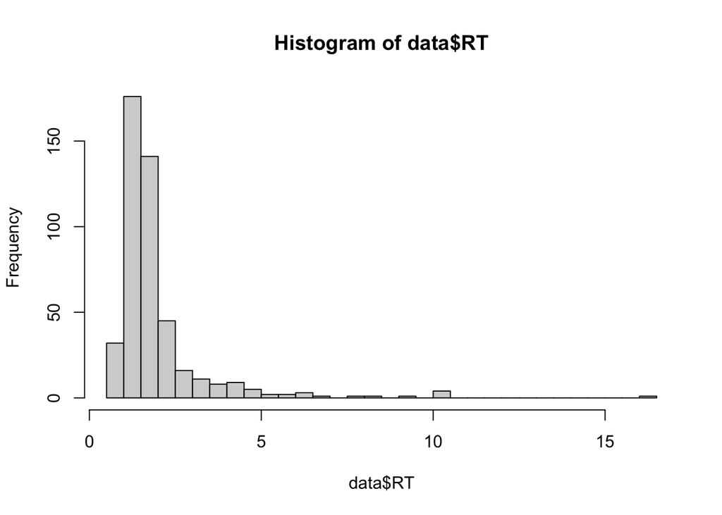

```r
hist(data$RT, breaks = 50)
```

```r
summary(data$RT)
```

```
##    Min. 1st Qu.  Median    Mean 3rd Qu.    Max.
##  0.6615  1.2269  1.5598  1.9473  1.9797 16.4559
```

```r
too_short <- which(data$RT<median(data$RT)-3*mad(data$RT))
too_long <- which(data$RT>median(data$RT)+3*mad(data$RT))
data2 <- data[-too_long,]
length(data2$RT)/length(data$RT)
```

```
## [1] 0.9063181
```

```r
too_short <- which(data$RT<median(data$RT)-6*mad(data$RT))
too_long <- which(data$RT>median(data$RT)+6*mad(data$RT))
data3 <- data[-too_long,]
length(data3$RT)/length(data$RT)
```

```
## [1] 0.9607843
```

```r
#... we tried several factors, and decided on doing a strict cut-off of the data at 95%:
keep_N <- ceiling(length(data$RT) * 0.95)
#sort(data$RT)
data_or_interm <- data %>% arrange(RT)
data_or <- data_or_interm[1:keep_N,]

# caluclate the factor
(max(data_or$RT)-median(data$RT)) / mad(data$RT)
```

```
## [1] 5.32165
```

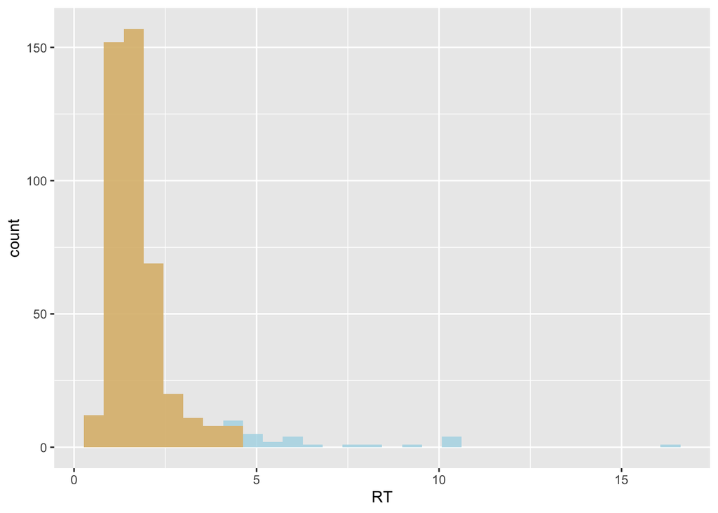

```r
ggplot() +
   geom_histogram(data, mapping = aes(RT), fill = 'lightblue', alpha = 0.8) +
   geom_histogram(data_or, mapping = aes(RT), fill = 'orange', alpha = 0.5)
```

Since a factor of 5 * the mad cuts off a bit too much data (~ 94%), but a factor of 6 leaves quite a few outliers remaining (18), we decided to implement a strict cut off of the data by keeping only the first 95% of sorted RT values. This corresponds to cut-off of ~ 5.32 * the mad.

#### Summary statistics

Let’s look at some summary statistics:

```r
summary(data_or$RT)
```

```
##    Min. 1st Qu.  Median    Mean 3rd Qu.    Max.
##  0.6615  1.2200  1.5410  1.6838  1.9189  4.3970
```

How do we expect the data to look, broken down by participant and dB level?

```r
RTdata <- data_or %>% group_by(participant, dB_ratio) %>%
                  summarise(median = median(RT),
                            mad = mad(RT),
                            quant = IQR(RT))
```

#### Plot

We’ll use [geom_boxplot()](https://ggplot2.tidyverse.org/reference/geom_boxplot.html) to visualize the summary statistics of RTs for each level of our dB manipulation.

We’ll also visualize the raw data by plotting the points with geom_point().

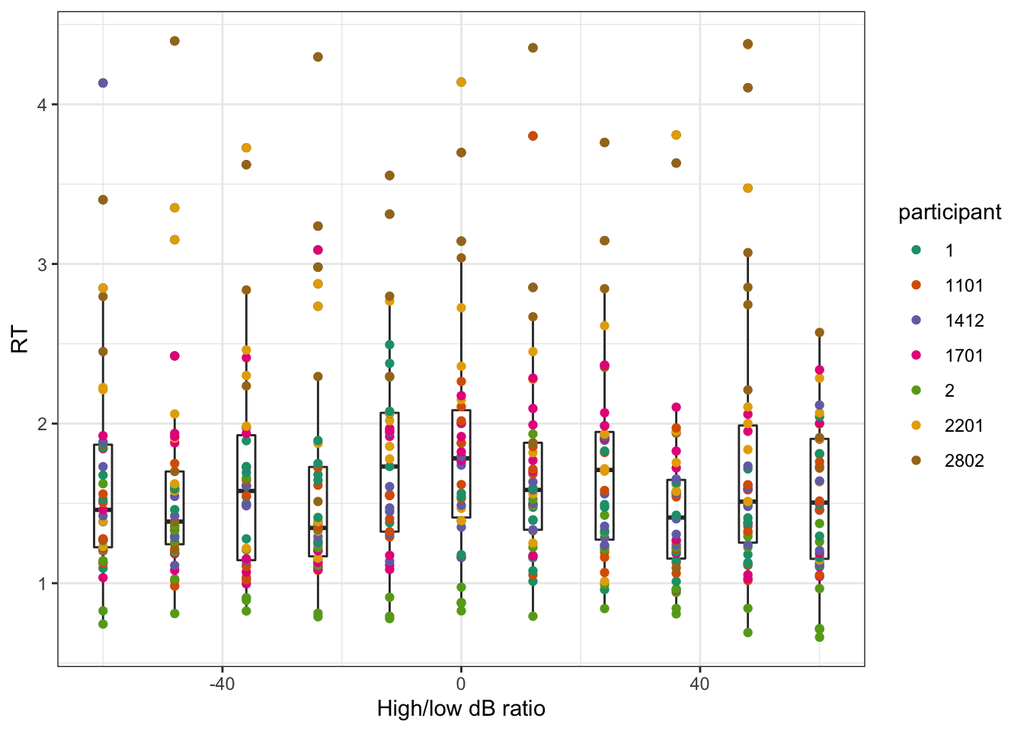

```r
ggplot(data_or) +
  geom_boxplot(aes(dB_ratio, RT, group = dB_ratio), width = 3) +
  geom_point(aes(dB_ratio, RT, color = participant)) +
  scale_x_continuous(name = "High/low dB ratio") +
  scale_color_brewer(palette = "Dark2") +
  theme_bw()
```

Challenge! Use [Raincloud](https://github.com/RainCloudPlots/RainCloudPlots) plots to also add a “half violin” to the side of each boxplot. Then, you’ll be visualizing the raw data, summary stats, and the distribution of responses for each level of dB.

### 2. Plain Linear Regression

Now, we’re going to model the effect of dB level (or stim_idx, doesn’t matter here…). What happens if we do a simple linear regression?

```r
RTmodel1 <- lm(RT ~ stim_idx, data = data_or)

summary(RTmodel1)
```

```
##
## Call:
## lm(formula = RT ~ stim_idx, data = data_or)
##
## Residuals:
##     Min      1Q  Median      3Q     Max
## -1.0254 -0.4615 -0.1447  0.2351  2.7156
##
## Coefficients:
##              Estimate Std. Error t value Pr(>|t|)
## (Intercept) 1.6801965  0.0703899  23.870   <2e-16 ***
## stim_idx    0.0006096  0.0103846   0.059    0.953
## ---
## Signif. codes:  0 '***' 0.001 '**' 0.01 '*' 0.05 '.' 0.1 ' ' 1
##
## Residual standard error: 0.6902 on 435 degrees of freedom
## Multiple R-squared:  7.923e-06,  Adjusted R-squared:  -0.002291
## F-statistic: 0.003446 on 1 and 435 DF,  p-value: 0.9532
```

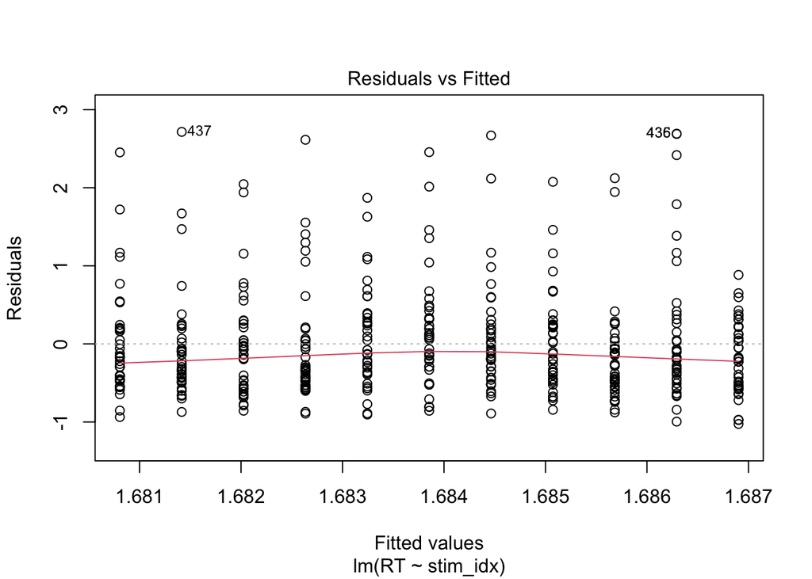

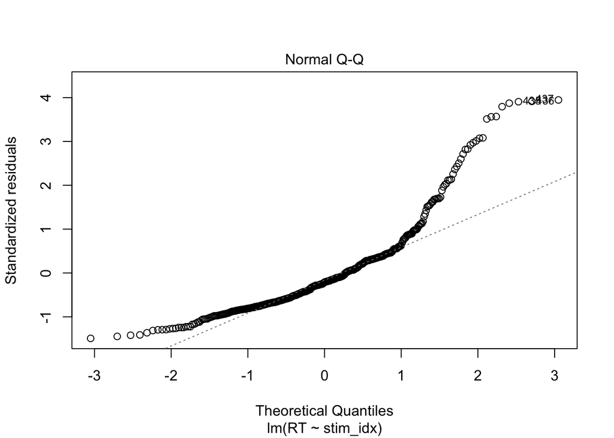

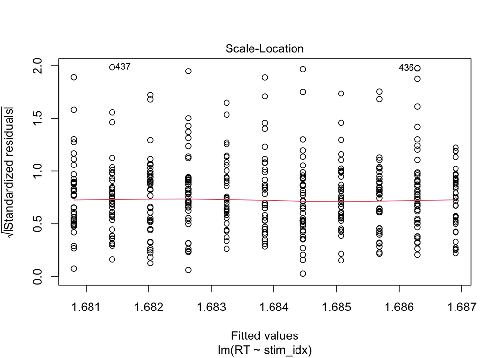

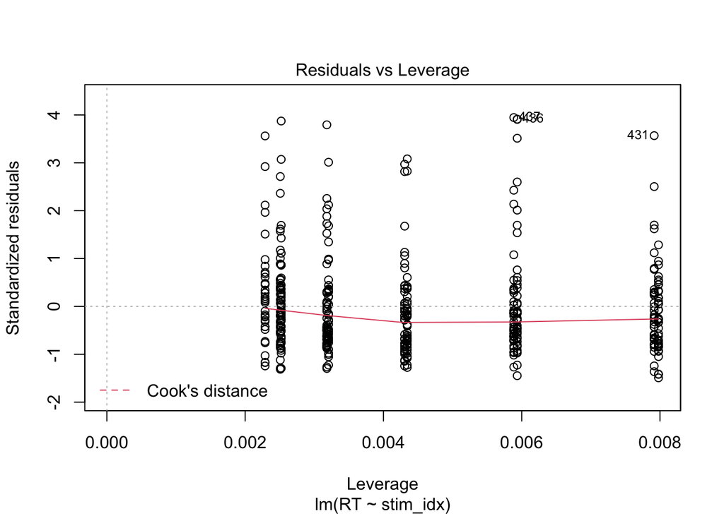

```r
plot(RTmodel1)
```

The `plot()` function from base R has an interesting behavior when it comes to model objects: it generates a bunch of diagnostic plots to help us determine if our model is a good fit for the data. Take a look at the plots and online - what are each of these plots telling us?

#### Predicted vs. Observed Values

As before, let’s visualize the predicted values from the model against our observed values.

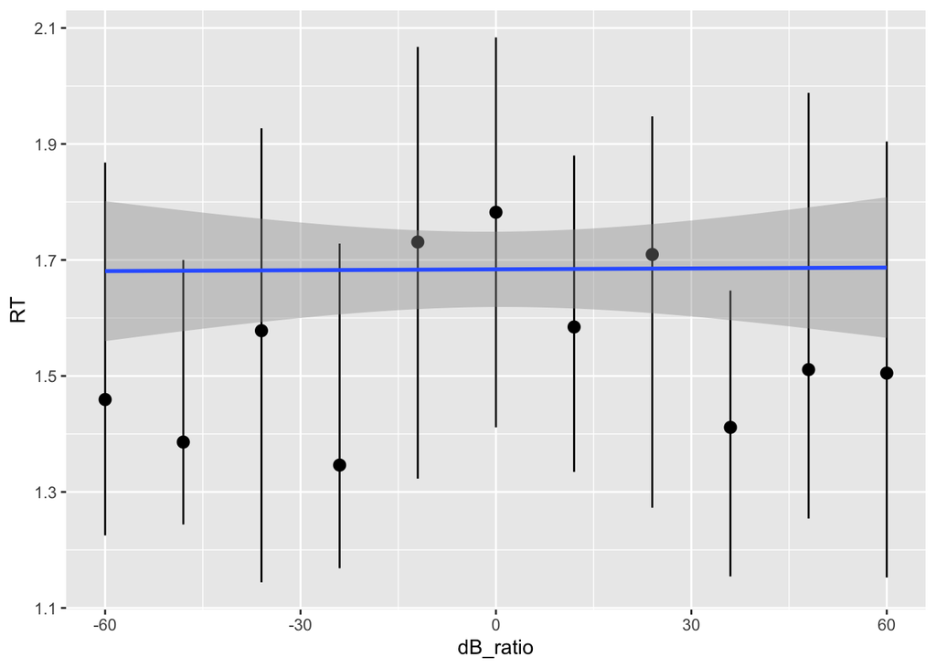

```r
predicted <- data.frame(RT_pred = predict(RTmodel1, data_or), dB_ratio=data_or$dB_ratio)

ggplot(data_or, aes(dB_ratio, RT)) +
  geom_pointrange(stat = "summary",
               fun.min = function(z) {quantile(z,0.25)},
               fun.max = function(z) {quantile(z,0.75)},
               fun = median) +
  geom_line(color='red',data = predicted, aes(x=dB_ratio, y=RT_pred)) +
  stat_smooth(method='lm', formula = y ~ x, size = 1)
```

Does this look like a good fit for the model?

A plain linear regression assumed a linear *relationship* between the predictor and outcome variable. But that’s not actually the relationship we observe, is it?

We predicted this too! We wrote:

> “To determine whether RTs are modulated by dB ratio (for the purposes of our study, an index of stimulus ambiguity), we will perform a polynomial linear regression with RTs as outcome variable and dB ratio as predictor.”

### 3. Polynomial Regression

Polynomial regression requires us to state the polynomial degree that defines the relationship of the predictor to the outcome variable.

Each time you add a degree, you can imagine you add another bend to the curve that we hope will capture the relationship between x and y, or dB ratio and responses.

Need a refresher on polynomial regression? Try [this](https://towardsdatascience.com/introduction-to-linear-regression-and-polynomial-regression-f8adc96f31cb).

So let’s give it a try:

In R, you can define that a predictor will be treated as a polynomial by wrapping the function `poly()` around the variable. The second argument to `poly()` is the polynomial order.

Go ahead and try this out. Visualize the predicted values, and play around with different orders…

Let’s give the polynomial regression that we planned in the pre-registration a chance. Since polynomial order = 1 is the same as linear regression, and as we increase the order, we risk overfitting fast, let’s start with an order = 2.

```r
RTmodel2 <- lm(RT ~ poly(stim_idx,2), data = data_or)

summary(RTmodel2)
```

```
##
## Call:
## lm(formula = RT ~ poly(stim_idx, 2), data = data_or)
##
## Residuals:
##     Min      1Q  Median      3Q     Max
## -0.9627 -0.4511 -0.1423  0.2490  2.7520
##
## Coefficients:
##                    Estimate Std. Error t value Pr(>|t|)
## (Intercept)         1.68385    0.03295  51.107   <2e-16 ***
## poly(stim_idx, 2)1  0.04052    0.68876   0.059   0.9531
## poly(stim_idx, 2)2 -1.16748    0.68876  -1.695   0.0908 .
## ---
## Signif. codes:  0 '***' 0.001 '**' 0.01 '*' 0.05 '.' 0.1 ' ' 1
##
## Residual standard error: 0.6888 on 434 degrees of freedom
## Multiple R-squared:  0.006585,   Adjusted R-squared:  0.002007
## F-statistic: 1.438 on 2 and 434 DF,  p-value: 0.2384
```

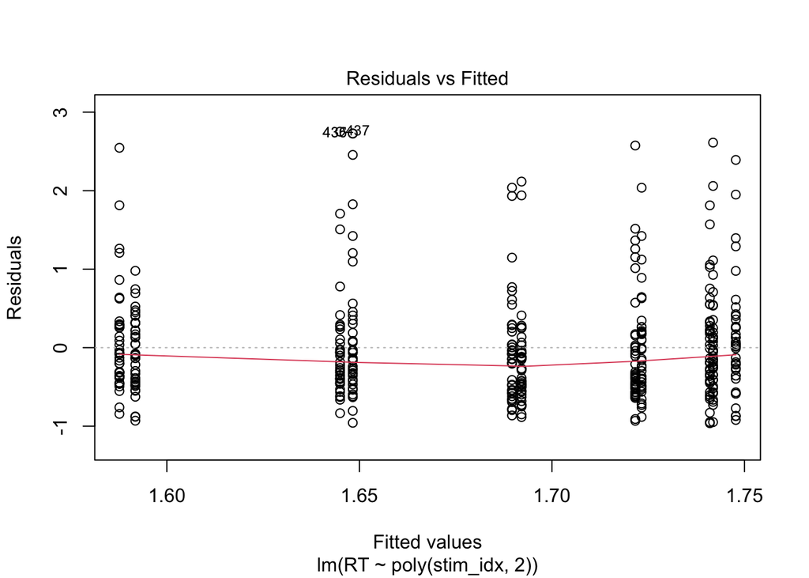

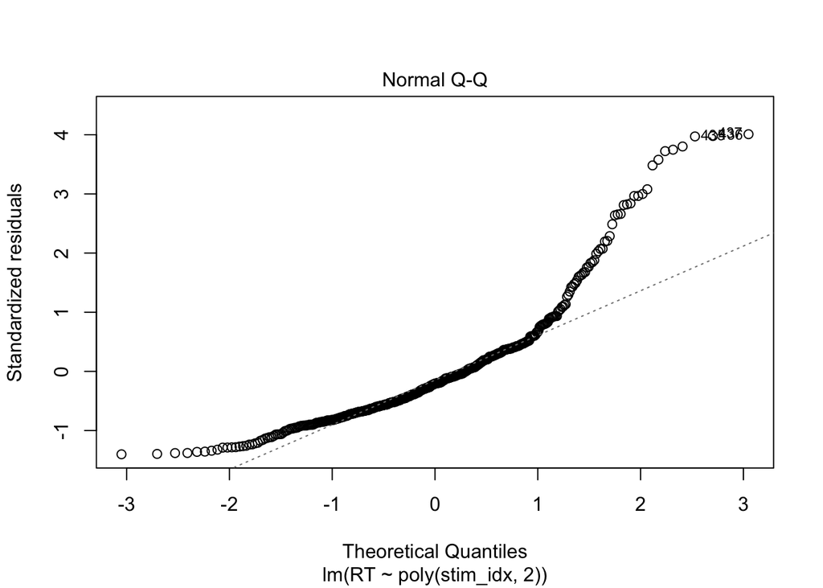

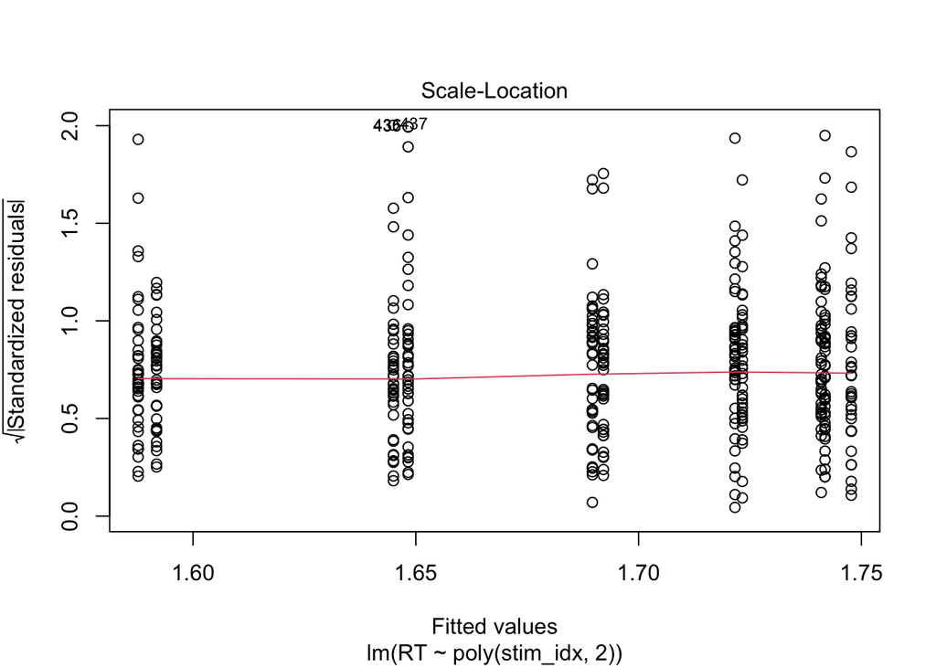

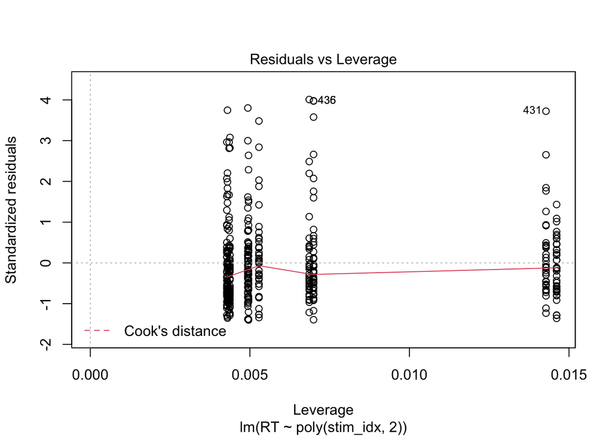

```r
plot(RTmodel2)
```

```r
# for plotting & calculating RSME
predicted2 <- data.frame(RT_pred = predict(RTmodel2, data_or), dB_ratio=data_or$dB_ratio)
```

What’s nice about the `lm()` function here is that it gives us separate coefficients and their test statistics for each polynomial order. This can help us figure out which order is contributing the most towards capturing the variance in the data.

Let’s quickly see what happens if we try different polynomial orders. Pay attention to the formula in the `stat_smooth()` layer of this `ggplot()`.

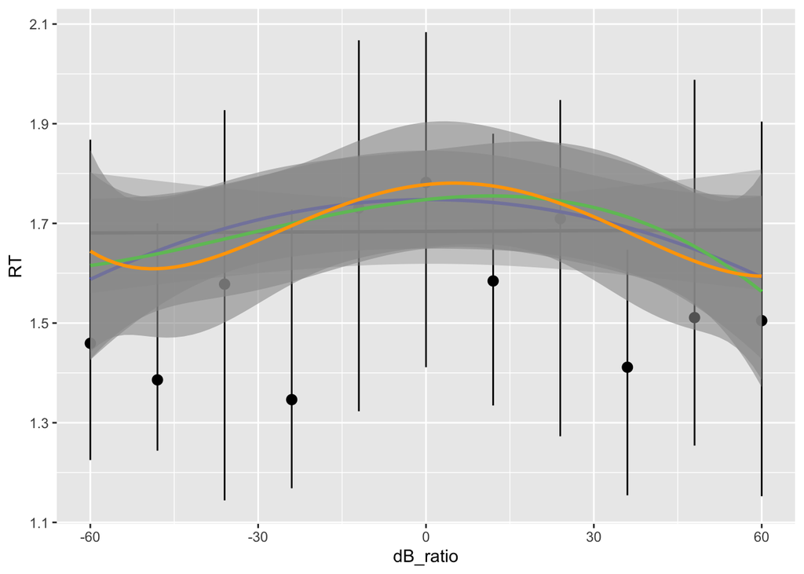

```r
ggplot(data_or, aes(dB_ratio, RT)) +
   geom_pointrange(stat = "summary",
                fun.min = function(z) {quantile(z,0.25)},
                fun.max = function(z) {quantile(z,0.75)},
                fun = median) +
   #geom_line(color='red',data = predicted2, aes(x=dB_ratio, y=RT_pred)) +
   stat_smooth(method='lm', formula = y ~ poly(x,1), size = 1, color = "black") +
   stat_smooth(method='lm', formula = y ~ poly(x,2), size = 1, alpha = 0.6, color = "blue") +
   stat_smooth(method='lm', formula = y ~ poly(x,3), size = 1, alpha = 0.6, color = "green") +
   stat_smooth(method='lm', formula = y ~ poly(x,4), size = 1, alpha = 0.6, color = "orange")
```

As before, we’re interested in the coefficients and their confidence intervals.

```r
coef(RTmodel2)
```

```
##        (Intercept) poly(stim_idx, 2)1 poly(stim_idx, 2)2
##         1.68384600         0.04052175        -1.16748464
```

```r
confint(RTmodel2, level=0.95)
```

```
##                        2.5 %    97.5 %
## (Intercept)         1.619089 1.7486030
## poly(stim_idx, 2)1 -1.313194 1.3942372
## poly(stim_idx, 2)2 -2.521200 0.1862309
```

How do we interpret the polynomial coefficients?

The predicted reaction time for a given dB level is given by the following equation:

$$RT = the intercept + first order polynomial* (dB level) + second order polynomial* (dB level)^2$$

#### Model Performance

The [Root Mean Square Error](https://www.r-bloggers.com/2021/07/how-to-calculate-root-mean-square-error-rmse-in-r/) is a useful metric to evaluate the goodness-of-fit of a linear model. Let’s break down the phrase from the end:

- we take the error: the difference between each observed and predicted value,
- square it,
- take the mean of those squared errors,
- then take the square root of that mean.

```r
# RSME for RTmodel2
sqrt(mean( (data_or$resp - predicted2$RT_pred)^2 ) )
```

```
## [1] 1.237682
```

In addition, compare the RMSE values for the models you fit:

```r
sqrt(mean( (data_or$resp - predicted$RT_pred)^2 ) )
```

```
## [1] 1.236231
```

Which has the lowest error? Well, they’re really the same actually. It looks like neither model is doing an excellent job of fitting the data, yet when looking at the data we can see why. There does not appear to be a clear pattern, or at least, not one we can observe with our sample size of 7 and the few trials we had per stimulus.

### Model Comparison

Think back to the last tutorial: what does model comparison using a Chi-square tell you?

```r
anova(RTmodel1, RTmodel2, test = "Chisq")
```

|  | Res.Df | RSS | Df | Sum of Sq | Pr(>Chi) |
| --- | --- | --- | --- | --- | --- |
| 1 | 435 | 207.2471 | NA | NA | NA |
| 2 | 434 | 205.8841 | 1 | 1.36302 | 0.09006433 |

What is the interpretation of this result in plain English?

### Writing it up…

[Values](https://www.statisticssolutions.com/reporting-statistics-in-apa-format/) to report: R^2, F value (F), degrees of freedom (numerator, denominator; in parentheses separated by a comma next to F), and significance level (p), β. Report the β and the corresponding t-test for that predictors for each predictor in the regression

For Example: “A polynomial regression analysis was used to test if the dB ratio level significantly predicted participants’ reaction times to the Yanny/Laurel 2AFC task. The results of the regression indicated the predictor”dB ratio" explained __ % of the variance (R2 = **, F(** ,**)=**, p __ ). It was found that __ [did not/significantly predict/ed RT (β = **, p** )."

# Resources

A great reference for modelling RTs [here.](https://lindeloev.github.io/shiny-rt/#1_opinion:_three_important_types_of_parameters)